# Product & Pricing Analysis

**Dataset:** Brazilian e-commerce marketplace, ~100k orders, Sept 2016 – Aug 2018.

**Two questions:**

1. **Beyond delivery, what else moves the score?** (price, freight ratio, product weight/size, photo count, description length, number of items)
2. **Which product categories carry high revenue, low revenue, and poor satisfaction?**

## 1. Imports & Defaults

```python
import warnings
from pathlib import Path

import numpy as np
import pandas as pd
import matplotlib.pyplot as plt
import matplotlib.patches as mpatches
from scipy import stats

warnings.filterwarnings("ignore")
pd.set_option("display.width", 160)
pd.set_option("display.max_columns", 30)

plt.rcParams.update({
    "figure.figsize": (9, 4.5),
    "figure.dpi": 110,
    "axes.spines.top": False,
    "axes.spines.right": False,
    "axes.grid": True,
    "grid.alpha": 0.3,
    "font.size": 10,
})

BLUE, ORANGE, GREEN, RED, GREY = "#2a78d6", "#eb6834", "#2ca02c", "#d62728", "#999999"

DATA = Path("../../processed_data")
FIGS = Path("figures")
FIGS.mkdir(exist_ok=True)

print("ready")
```

```
ready
```

## 2. Load Data

```python
# Load the rich master orders table (already preprocessed)
master   = pd.read_csv(DATA / "master_orders.csv", parse_dates=["order_purchase_timestamp"])

# Load raw product details (weight, size, photos, description length)
# products.csv already contains product_category_name_english — no cats re-merge needed
products = pd.read_csv(DATA / "products.csv")
items    = pd.read_csv(DATA / "order_items.csv")

for name, df in [("master_orders", master), ("products", products), ("order_items", items)]:
    print(f"{name:15s} {len(df):>7,} rows  {df.shape[1]:>2} cols")

print("\nmaster columns:", list(master.columns))
```

[output not shown]

## 3. Build the Analytical Base Table

```python
# Keep only delivered orders with a review score
base = master[
    (master.order_status == "delivered") &
    master.review_score.notna()
].copy()
print(f"Delivered orders with a review: {len(base):,}")

# For each order pick the highest-value item's product (proxy for main product)
top_item = (
    items.sort_values("price", ascending=False)
         .drop_duplicates("order_id")[["order_id", "product_id"]]
)

# Attach product features — products.csv already has product_category_name_english
base = (
    base
    .merge(top_item, on="order_id", how="left")
    .merge(
        products[[
            "product_id",
            "product_category_name_english",
            "product_name_length",
            "product_description_length",
            "product_photos_qty",
            "product_weight_g",
            "product_length_cm",
            "product_height_cm",
            "product_width_cm",
            "product_volume_cm3",
        ]],
        on="product_id",
        how="left",
    )
)

# Fill category from master where product join is missing
base["category"] = base["product_category_name_english"].fillna(
    base["primary_category"]
).fillna("unknown")

# Derived columns
base["is_bad"]    = base.review_score <= 2
base["is_ontime"] = base.delay_days <= 0
base["revenue"]   = base.total_price   # already per-order sum

# Product photos — cap outliers for plotting
base["photos_capped"] = base.product_photos_qty.clip(upper=10)

print(f"Base with product features: {len(base):,} orders")
print(f"Missing product join: {base.product_weight_g.isna().sum():,} rows ({base.product_weight_g.isna().mean():.1%})")
print(base[["review_score", "is_bad", "total_price", "freight_ratio",
             "product_weight_g", "product_volume_cm3",
             "product_photos_qty", "product_description_length", "n_items"]].describe().round(2))
```

```
Delivered orders with a review: 95,832
```

```
Base with product features: 95,832 orders
Missing product join: 0 rows (0.0%)
       review_score  total_price  freight_ratio  product_weight_g  product_volume_cm3  product_photos_qty  product_description_length   n_items
count      95832.00     95832.00       95832.00          95832.00            95832.00            95832.00                    95832.00  95832.00
mean           4.16       136.80           0.31           2107.22            15200.26                2.23                      791.69      1.14
std            1.28       207.78           0.31           3762.35            23323.22                1.74                      649.88      0.53
min            1.00         0.85           0.00              0.00              168.00                1.00                        4.00      1.00
25%            4.00        45.90           0.13            300.00             2816.00                1.00                      353.00      1.00
50%            5.00        86.25           0.22            700.00             6400.00                1.00                      601.00      1.00
75%            5.00       149.90           0.38           1813.00            18375.00                3.00                      990.00      1.00
max            5.00     13440.00          21.45          40425.00           296208.00               20.00                     3992.00     21.00
```

## 4. EDA on Key Variables

```
Platform bad-review rate (1-2 stars): 12.76%
Total orders in base               : 95,832
Total bad reviews                  : 12,225
```

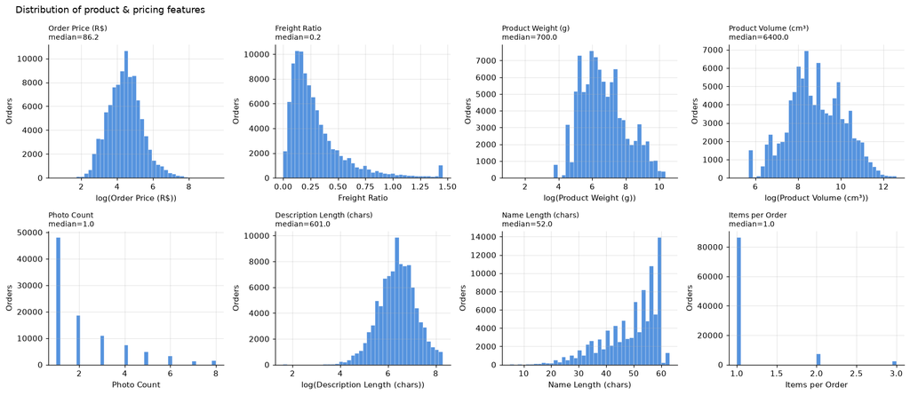

```python
# Overall bad-review rate (baseline)
BAD_RATE = base.is_bad.mean()
print(f"Platform bad-review rate (1-2 stars): {BAD_RATE:.2%}")
print(f"Total orders in base               : {len(base):,}")
print(f"Total bad reviews                  : {base.is_bad.sum():,}")
print()

# EDA: distribution of the main numeric drivers
fig, axes = plt.subplots(2, 4, figsize=(16, 7))
cols_plot = [
    ("total_price",                "Order Price (R$)",        True),
    ("freight_ratio",              "Freight Ratio",           False),
    ("product_weight_g",           "Product Weight (g)",      True),
    ("product_volume_cm3",         "Product Volume (cm³)",    True),
    ("product_photos_qty",         "Photo Count",             False),
    ("product_description_length", "Description Length (chars)", True),
    ("product_name_length",        "Name Length (chars)",     False),
    ("n_items",                    "Items per Order",         False),
]

for ax, (col, label, log) in zip(axes.flat, cols_plot):
    vals = base[col].dropna()
    if log:
        vals = vals[vals > 0]
        ax.hist(np.log1p(vals), bins=40, color=BLUE, alpha=0.8, edgecolor="white", linewidth=0.3)
        ax.set_xlabel(f"log({label})")
    else:
        ax.hist(vals.clip(upper=vals.quantile(0.99)), bins=40, color=BLUE, alpha=0.8,
                edgecolor="white", linewidth=0.3)
        ax.set_xlabel(label)
    ax.set_ylabel("Orders")
    ax.set_title(f"{label}\nmedian={vals.median():.1f}", fontsize=9, loc="left")

fig.suptitle("Distribution of product & pricing features", fontsize=12, x=0.02, ha="left")
fig.tight_layout()
plt.savefig(FIGS / "eda_distributions.png", bbox_inches="tight")
plt.show()
```

# Question 1 — Beyond Delivery, What Else Moves the Score?

We isolate **on-time orders** to remove the dominant delivery signal, then ask: among orders that arrived on time, which product/pricing features still predict a bad review?

We do this in two ways:

- **Bin-level bad-review rates** — visualise how rate changes across bins of each feature
- **Point-biserial correlation** — rank the features by effect size

```python
# Restrict to on-time orders for both halves of Q1
ontime = base[base.is_ontime & base.delay_days.notna()].copy()
late   = base[~base.is_ontime & base.delay_days.notna()].copy()

print(f"On-time orders  : {len(ontime):,}  bad-review rate: {ontime.is_bad.mean():.2%}")
print(f"Late orders     : {len(late):,}  bad-review rate: {late.is_bad.mean():.2%}")
print(f"\nOn-time base is clean of the delivery excuse — findings here are product/price-driven.")
```

```
On-time orders  : 89,443  bad-review rate: 9.22%
Late orders     : 6,381  bad-review rate: 62.31%

On-time base is clean of the delivery excuse — findings here are product/price-driven.
```

```python
# Helper: compute bad rate by quantile bins, return DataFrame for plotting
def bad_by_bins(df, col, n_bins=5, min_n=100, log=False):
    sub = df[[col, "is_bad"]].dropna()
    if log:
        sub = sub[sub[col] > 0].copy()
        sub[col] = np.log1p(sub[col])
    try:
        sub["bin"] = pd.qcut(sub[col], n_bins, duplicates="drop")
    except Exception:
        sub["bin"] = pd.cut(sub[col], n_bins)
    tbl = sub.groupby("bin", observed=True).agg(
        n=("is_bad", "size"),
        bad_rate=("is_bad", "mean")
    ).reset_index()
    tbl = tbl[tbl.n >= min_n]
    tbl["mid"] = tbl["bin"].apply(lambda b: b.mid)
    return tbl
```

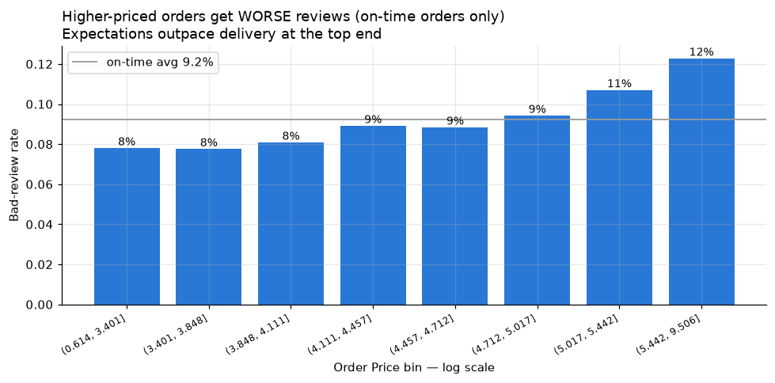

```
Point-biserial r(price vs is_bad) = 0.048  p=0.0000
```

```python
# --- Price ---
tbl_price = bad_by_bins(ontime, "total_price", n_bins=8, log=True)

fig, ax = plt.subplots()
ax.bar(range(len(tbl_price)), tbl_price.bad_rate, color=BLUE)
for i, row in tbl_price.iterrows():
    ax.annotate(f"{row.bad_rate:.0%}", (i, row.bad_rate), ha="center", va="bottom", fontsize=9)
ax.axhline(ontime.is_bad.mean(), color=GREY, lw=1.2, label=f"on-time avg {ontime.is_bad.mean():.1%}")
ax.set_xticks(range(len(tbl_price)))
ax.set_xticklabels([str(b.bin) for _, b in tbl_price.iterrows()], rotation=30, ha="right", fontsize=8)
ax.set_xlabel("Order Price bin — log scale"); ax.set_ylabel("Bad-review rate")
ax.legend()
ax.set_title("Higher-priced orders get WORSE reviews (on-time orders only)\n"
             "Expectations outpace delivery at the top end", loc="left")
plt.tight_layout()
plt.savefig(FIGS / "q1_price.png", bbox_inches="tight")
plt.show()

r_price, p_price = stats.pointbiserialr(ontime.is_bad, np.log1p(ontime.total_price))
print(f"Point-biserial r(price vs is_bad) = {r_price:.3f}  p={p_price:.4f}")
```

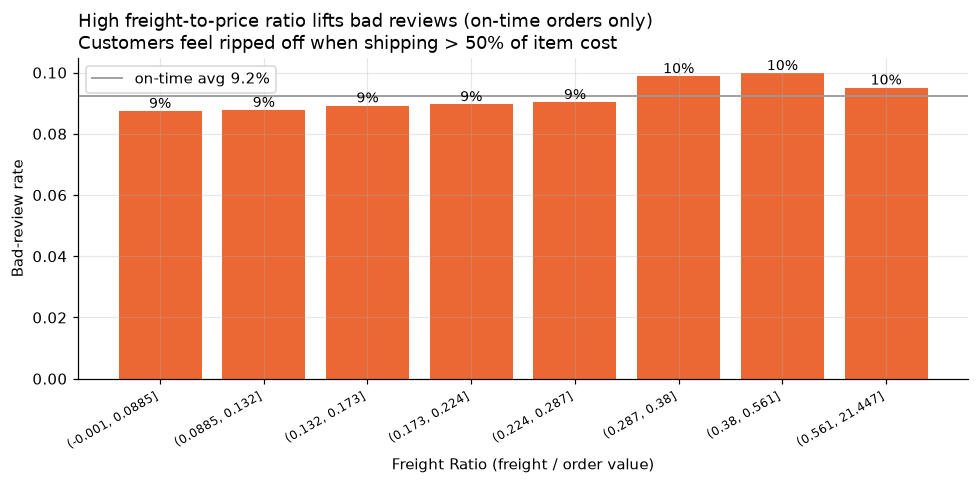

```
Point-biserial r(freight_ratio vs is_bad) = 0.012  p=0.0003
```

```python
# --- Freight Ratio ---
tbl_fr = bad_by_bins(ontime, "freight_ratio", n_bins=8, log=False)

fig, ax = plt.subplots()
ax.bar(range(len(tbl_fr)), tbl_fr.bad_rate, color=ORANGE)
for i, row in tbl_fr.iterrows():
    ax.annotate(f"{row.bad_rate:.0%}", (i, row.bad_rate), ha="center", va="bottom", fontsize=9)
ax.axhline(ontime.is_bad.mean(), color=GREY, lw=1.2, label=f"on-time avg {ontime.is_bad.mean():.1%}")
ax.set_xticks(range(len(tbl_fr)))
ax.set_xticklabels([str(b.bin) for _, b in tbl_fr.iterrows()], rotation=30, ha="right", fontsize=8)
ax.set_xlabel("Freight Ratio (freight / order value)"); ax.set_ylabel("Bad-review rate")
ax.legend()
ax.set_title("High freight-to-price ratio lifts bad reviews (on-time orders only)\n"
             "Customers feel ripped off when shipping > 50% of item cost", loc="left")
plt.tight_layout()
plt.savefig(FIGS / "q1_freight_ratio.png", bbox_inches="tight")
plt.show()

r_fr, p_fr = stats.pointbiserialr(ontime.is_bad, ontime.freight_ratio)
print(f"Point-biserial r(freight_ratio vs is_bad) = {r_fr:.3f}  p={p_fr:.4f}")
```

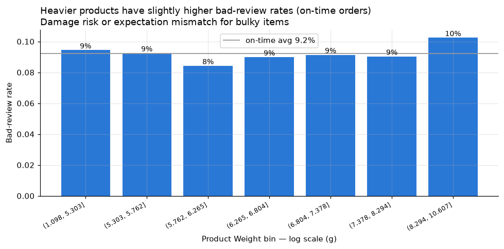

```
Point-biserial r(weight vs is_bad) = 0.012  p=0.0002
```

```python
# --- Product Weight ---
sub_wt = ontime.dropna(subset=["product_weight_g"])
tbl_wt = bad_by_bins(sub_wt, "product_weight_g", n_bins=7, log=True)

fig, ax = plt.subplots()
ax.bar(range(len(tbl_wt)), tbl_wt.bad_rate, color=BLUE)
for i, row in tbl_wt.iterrows():
    ax.annotate(f"{row.bad_rate:.0%}", (i, row.bad_rate), ha="center", va="bottom", fontsize=9)
ax.axhline(sub_wt.is_bad.mean(), color=GREY, lw=1.2, label=f"on-time avg {sub_wt.is_bad.mean():.1%}")
ax.set_xticks(range(len(tbl_wt)))
ax.set_xticklabels([str(b.bin) for _, b in tbl_wt.iterrows()], rotation=30, ha="right", fontsize=8)
ax.set_xlabel("Product Weight bin — log scale (g)"); ax.set_ylabel("Bad-review rate")
ax.legend()
ax.set_title("Heavier products have slightly higher bad-review rates (on-time orders)\n"
             "Damage risk or expectation mismatch for bulky items", loc="left")
plt.tight_layout()
plt.savefig(FIGS / "q1_weight.png", bbox_inches="tight")
plt.show()

r_wt, p_wt = stats.pointbiserialr(sub_wt.is_bad, np.log1p(sub_wt.product_weight_g))
print(f"Point-biserial r(weight vs is_bad) = {r_wt:.3f}  p={p_wt:.4f}")
```